# Pinellas County Aquatic Preserve

SEACAR Water Quality Analysis

Last compiled on 15 July, 2026

# Indicators

## Nutrients

### Total Nitrogen - Discrete

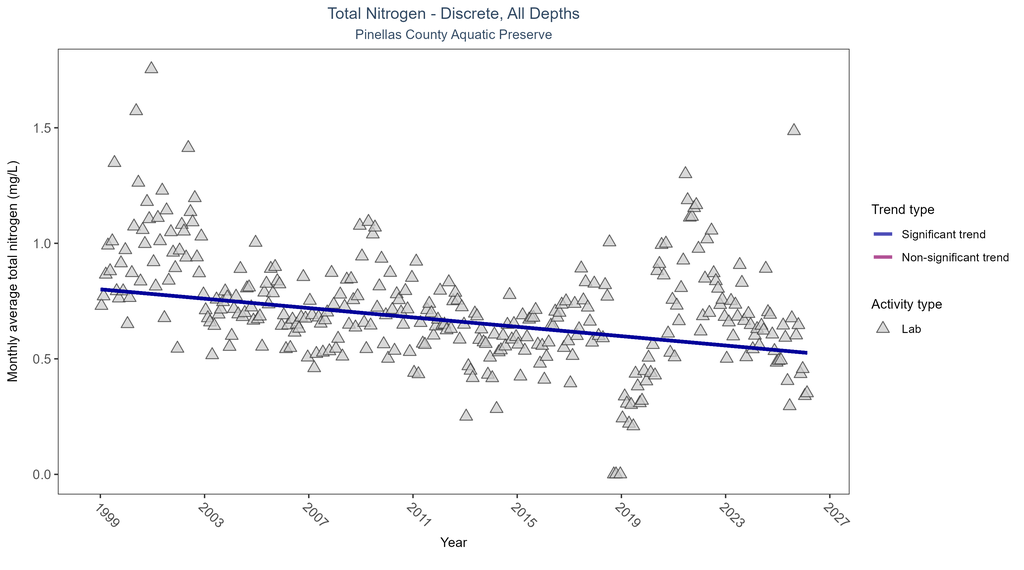

Scatter plot of monthly average total nitrogen over time. If the time series included ten or more years of discrete observations, a significant (blue) or non-significant (magenta) trend line is also shown. Only nitrogen values obtained from laboratory analyses (triangles) are included in the plot.

Table:

Monthly average total nitrogen decreased by 0.01 mg/L per year.

| Activity Type | Statistical Trend | Sample Count | Years with Data | Period of Record | Median Result Value | Tau | Sen Intercept | Sen Slope | P |
| --- | --- | --- | --- | --- | --- | --- | --- | --- | --- |
| Lab | Decreasing trend | 16863 | 28 | 1999 - 2026 | 0.586 | -0.27461 | 0.80079 | -0.01013 | 0 |

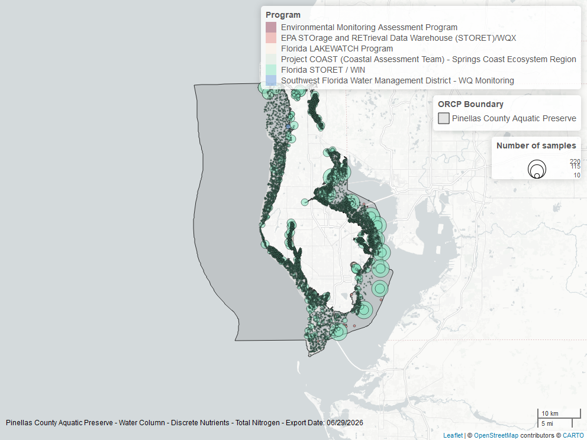

Map showing location of discrete water quality sampling locations within the boundaries of *Pinellas County Aquatic Preserve*. The bubble size on the maps above reflect the amount of data available at each sampling site.

### Total Phosphorus - Discrete

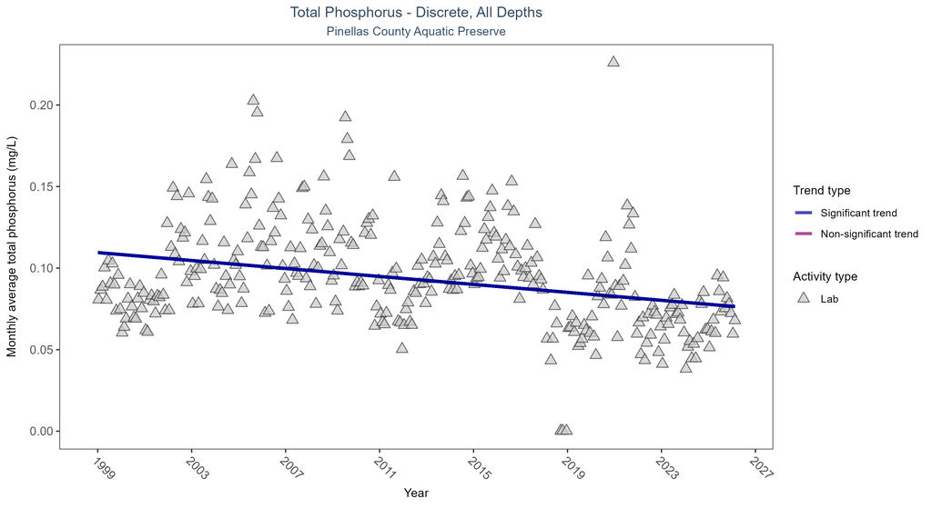

Scatter plot of monthly average total phosphorus over time. If the time series included ten or more years of discrete observations, a significant (blue) or non-significant (magenta) trend line is also shown. Only phosphorus values obtained from laboratory analyses (triangles) are included in the plot.

Table:

Monthly average total phosphorus decreased by less than 0.01 mg/L per year.

| Activity Type | Statistical Trend | Sample Count | Years with Data | Period of Record | Median Result Value | Tau | Sen Intercept | Sen Slope | P |
| --- | --- | --- | --- | --- | --- | --- | --- | --- | --- |
| Lab | Decreasing trend | 16744 | 28 | 1999 - 2026 | 0.087 | -0.26107 | 0.10953 | -0.00122 | 0 |

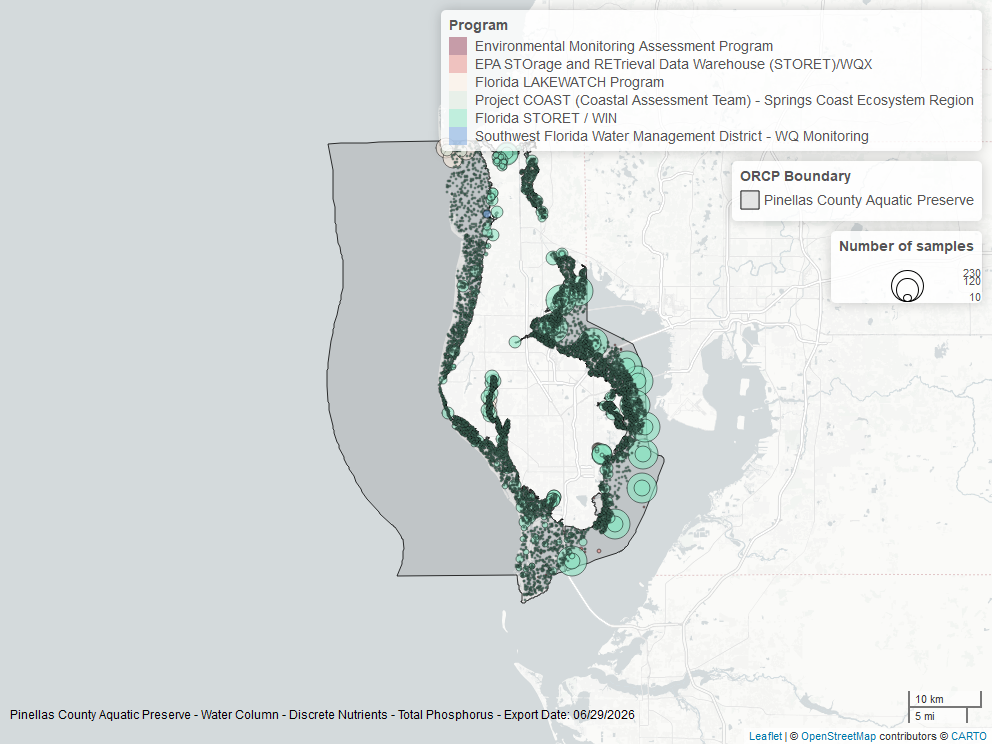

Map showing location of discrete water quality sampling locations within the boundaries of *Pinellas County Aquatic Preserve*. The bubble size on the maps above reflect the amount of data available at each sampling site.

## Water Quality

### Dissolved Oxygen - Discrete

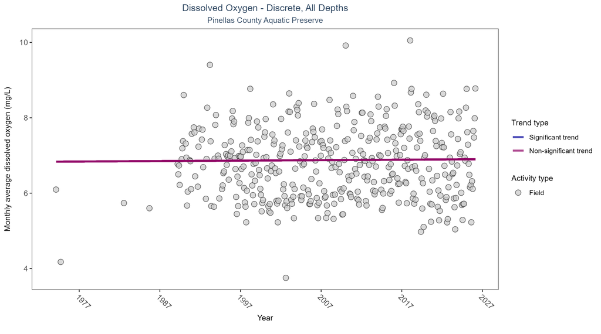

Scatter plot of monthly average dissolved oxygen over time. If the time series included ten or more years of discrete observations, a significant (blue) or non-significant (magenta) trend line is also shown. Only dissolved oxygen values measured in the field (circles) are included in the plot.

Table:

Dissolved oxygen showed no detectable trend between 1974 and 2026.

| Activity Type | Statistical Trend | Sample Count | Years with Data | Period of Record | Median Result Value | Tau | Sen Intercept | Sen Slope | P |
| --- | --- | --- | --- | --- | --- | --- | --- | --- | --- |
| Field | No detectable trend | 97566 | 41 | 1974 - 2026 | 6.6 | 0.02498 | 6.83568 | 0.00122 | 0.5335 |

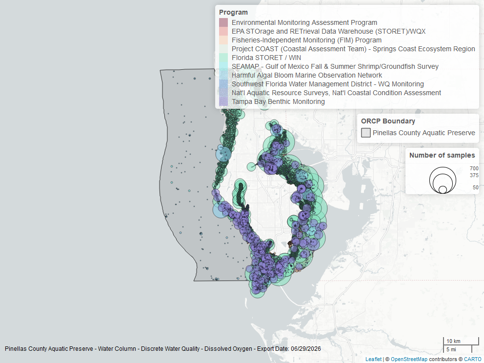

Map showing location of discrete water quality sampling locations within the boundaries of *Pinellas County Aquatic Preserve*. The bubble size on the maps above reflect the amount of data available at each sampling site.

### Dissolved Oxygen Saturation - Discrete

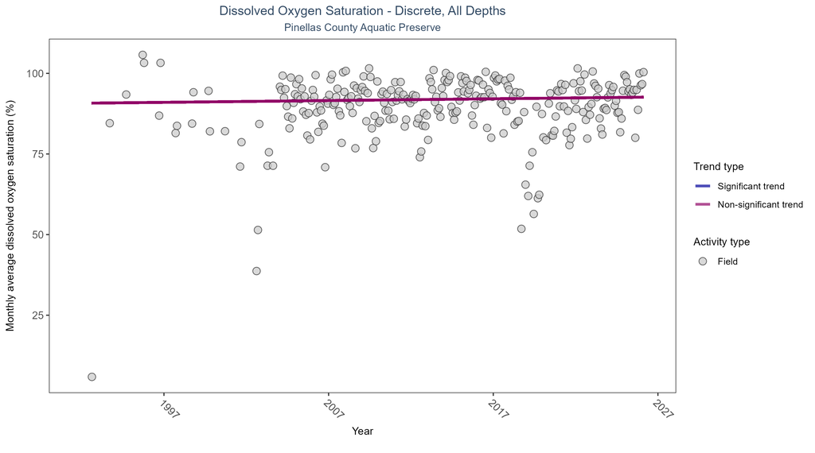

Scatter plot of monthly average dissolved oxygen saturation over time. If the time series included ten or more years of discrete observations, a significant (blue) or non-significant (magenta) trend line is also shown. Only dissolved oxygen saturation values measured in the field (circles) are included in the plot.

Table:

Dissolved oxygen saturation showed no detectable trend between 1992 and 2026.

| Activity Type | Statistical Trend | Sample Count | Years with Data | Period of Record | Median Result Value | Tau | Sen Intercept | Sen Slope | P |
| --- | --- | --- | --- | --- | --- | --- | --- | --- | --- |
| Field | No detectable trend | 32108 | 35 | 1992 - 2026 | 91.1 | 0.05845 | 90.73554 | 0.05513 | 0.2278 |

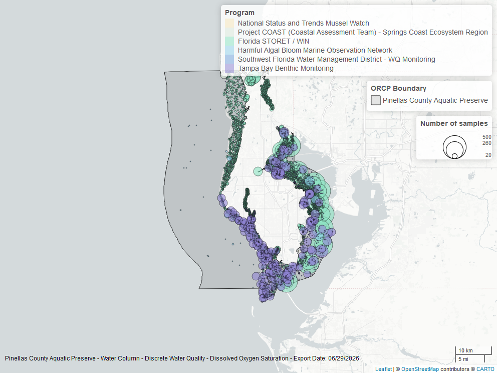

Map showing location of discrete water quality sampling locations within the boundaries of *Pinellas County Aquatic Preserve*. The bubble size on the maps above reflect the amount of data available at each sampling site.

### Salinity - Discrete

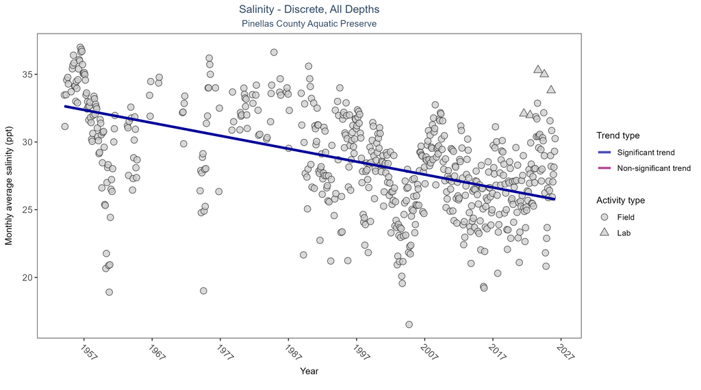

Scatter plot of monthly average salinity over time. If the time series included ten or more years of discrete observations, significant (blue) or non-significant (magenta) trend lines are also shown. Discrete salinity values derived from grab samples analyzed in the field (circles) or the laboratory (triangles) are both included in the plot.

Table:

Monthly average salinity decreased by 0.1 ppt per year.

| Activity Type | Statistical Trend | Sample Count | Years with Data | Period of Record | Median Result Value | Tau | Sen Intercept | Sen Slope | P |
| --- | --- | --- | --- | --- | --- | --- | --- | --- | --- |
| All | Decreasing trend | 97135 | 66 | 1954 - 2026 | 28.95 | -0.35856 | 32.65474 | -0.0955 | 0 |

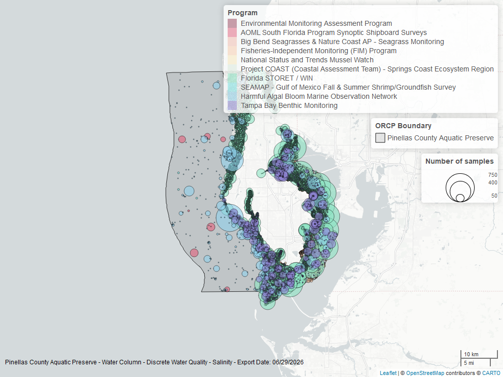

Map showing location of discrete water quality sampling locations within the boundaries of *Pinellas County Aquatic Preserve*. The bubble size on the maps above reflect the amount of data available at each sampling site.

### Water Temperature - Continuous

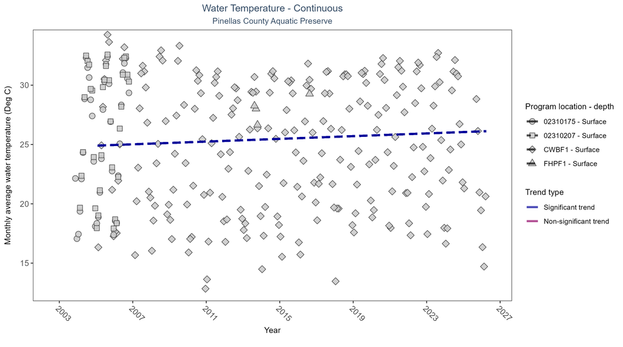

Scatter plot of monthly average water temperature over time at continuously monitored program locations. Each location is analyzed separately, with significant (blue) or non-significant (magenta) trend lines shown for time series that included five or more years of observations.

Table:

At one program location, monthly average water temperature increased by 0.06°C per year. There was insufficient data to fit a model for three locations.

| Program Location | Statistical Trend | Sample Count | Years with Data | Period of Record | Median Result Value | Tau | Sen Intercept | Sen Slope | P |
| --- | --- | --- | --- | --- | --- | --- | --- | --- | --- |
| CWBF1 | Increasing trend | 1462490 | 22 | 2005 - 2026 | 25.20 | 0.16 | 24.9 | 0.06 | 0 |
| FHPF1 | Insufficient data | 12636 | 2 | 2013 - 2016 | 27.90 | - | - | - | - |
| 02310175 | Insufficient data | 1421 | 4 | 2003 - 2006 | 26.50 | - | - | - | - |
| 02310207 | Insufficient data | 1424 | 3 | 2004 - 2006 | 27.55 | - | - | - | - |

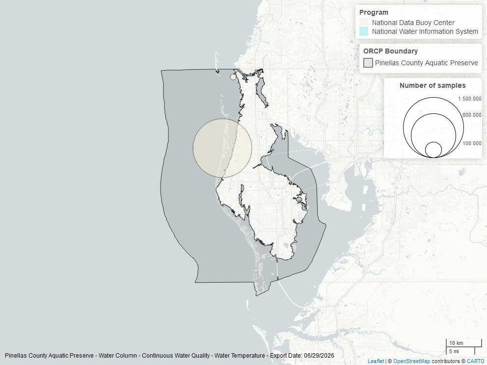

Map showing location of water temperature continuous water quality sampling locations within the boundaries of *Pinellas County Aquatic Preserve*. The bubble size on the maps above reflect the amount of data available at each sampling site.

### Water Temperature - Discrete

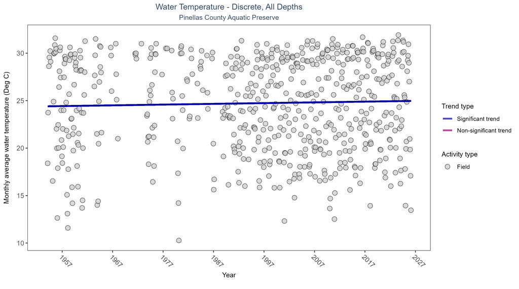

Scatter plot of monthly average water temperature over time. If the time series included ten or more years of discrete observations, a significant (blue) or non-significant (magenta) trend line is also shown. Only water temperature measurements taken in the field (circles) are included in the plot.

Table:

Monthly average water temperature increased by 0.01°C per year.

| Activity Type | Statistical Trend | Sample Count | Years with Data | Period of Record | Median Result Value | Tau | Sen Intercept | Sen Slope | P |
| --- | --- | --- | --- | --- | --- | --- | --- | --- | --- |
| Field | Increasing trend | 103566 | 69 | 1954 - 2026 | 26.53 | 0.08715 | 24.4036 | 0.00782 | 0.0022 |

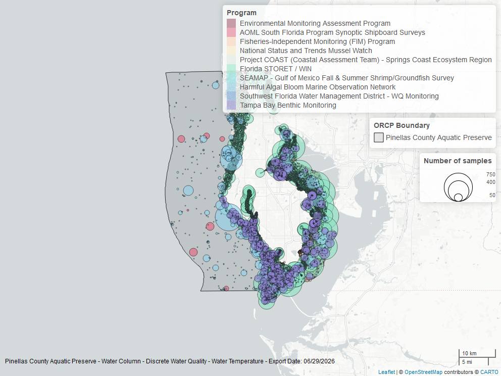

Map showing location of discrete water quality sampling locations within the boundaries of *Pinellas County Aquatic Preserve*. The bubble size on the maps above reflect the amount of data available at each sampling site.

### pH - Discrete

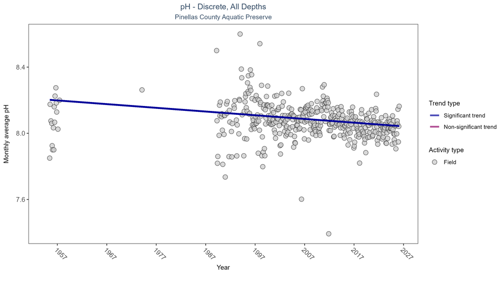

Scatter plot of monthly average pH over time. If the time series included ten or more years of discrete observations, a significant (blue) or non-significant (magenta) trend line is also shown. Only pH values measured in the field (circles) are included in the plot.

Table:

Monthly average pH decreased by less than 0.01 pH units per year.

| Activity Type | Statistical Trend | Sample Count | Years with Data | Period of Record | Median Result Value | Tau | Sen Intercept | Sen Slope | P |
| --- | --- | --- | --- | --- | --- | --- | --- | --- | --- |
| Field | Decreasing trend | 92809 | 42 | 1955 - 2026 | 8.1 | -0.21357 | 8.20321 | -0.00224 | 0 |

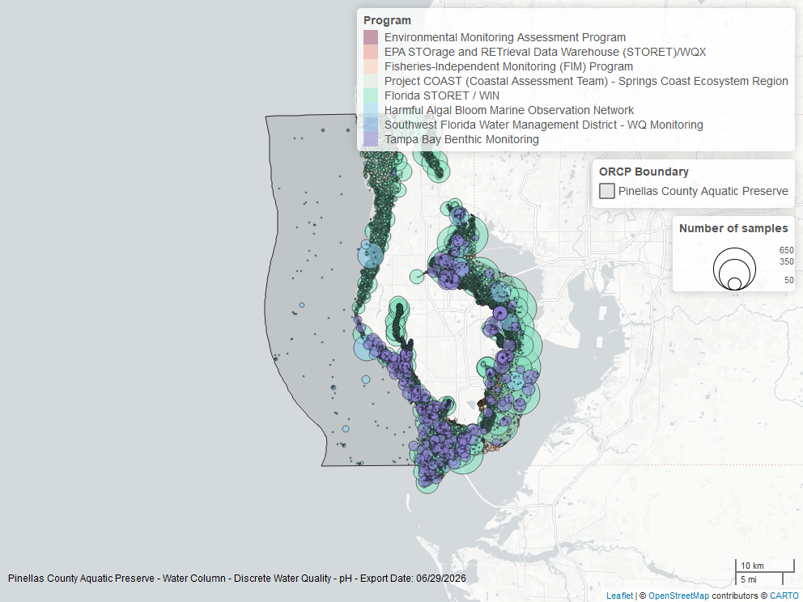

Map showing location of discrete water quality sampling locations within the boundaries of *Pinellas County Aquatic Preserve*. The bubble size on the maps above reflect the amount of data available at each sampling site.

### Specific Conductivity - Continuous

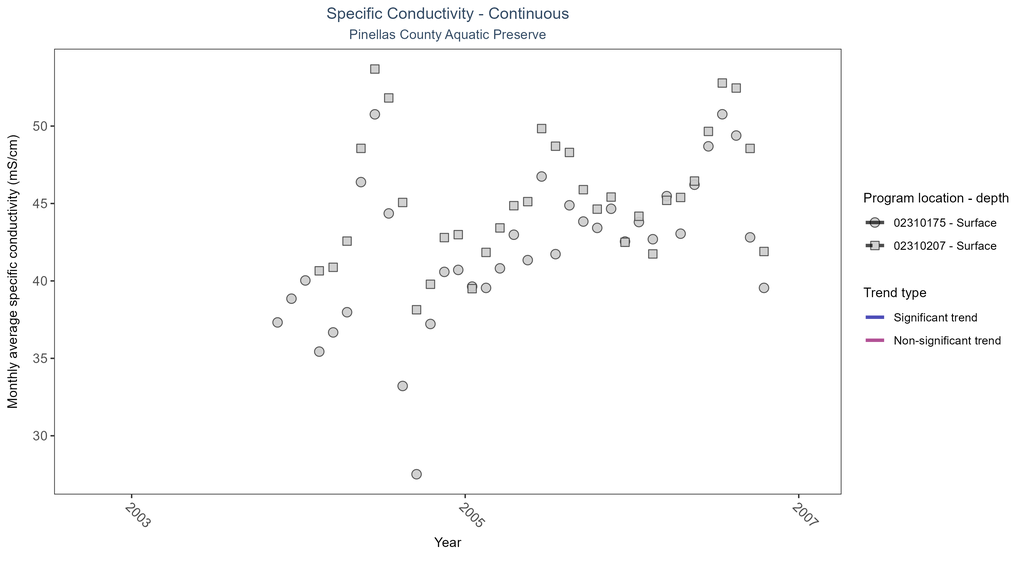

Scatter plot of monthly average specific conductivity over time at continuously monitored program locations. Each location is analyzed separately, with significant (blue) or non-significant (magenta) trend lines shown for time series that included five or more years of observations.

Table:

There was insufficient data to fit a model for two locations.

| Program Location | Statistical Trend | Sample Count | Years with Data | Period of Record | Median Result Value | Tau | Sen Intercept | Sen Slope | P |
| --- | --- | --- | --- | --- | --- | --- | --- | --- | --- |
| 02310175 | Insufficient data | 1876 | 4 | 2003 - 2006 | 42.3 | - | - | - | - |
| 02310207 | Insufficient data | 1502 | 3 | 2004 - 2006 | 45.6 | - | - | - | - |

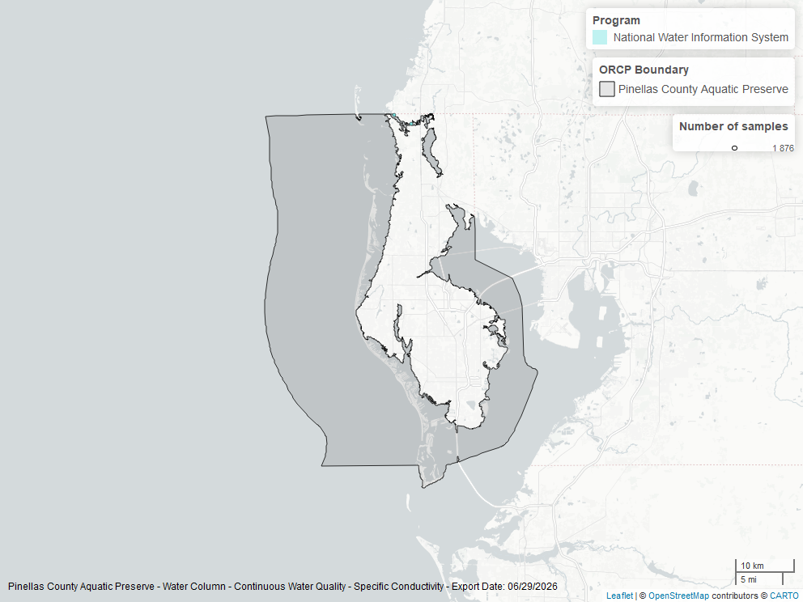

Map showing location of specific conductivity continuous water quality sampling locations within the boundaries of *Pinellas County Aquatic Preserve*. The bubble size on the maps above reflect the amount of data available at each sampling site.

## Water Clarity

### Turbidity - Discrete

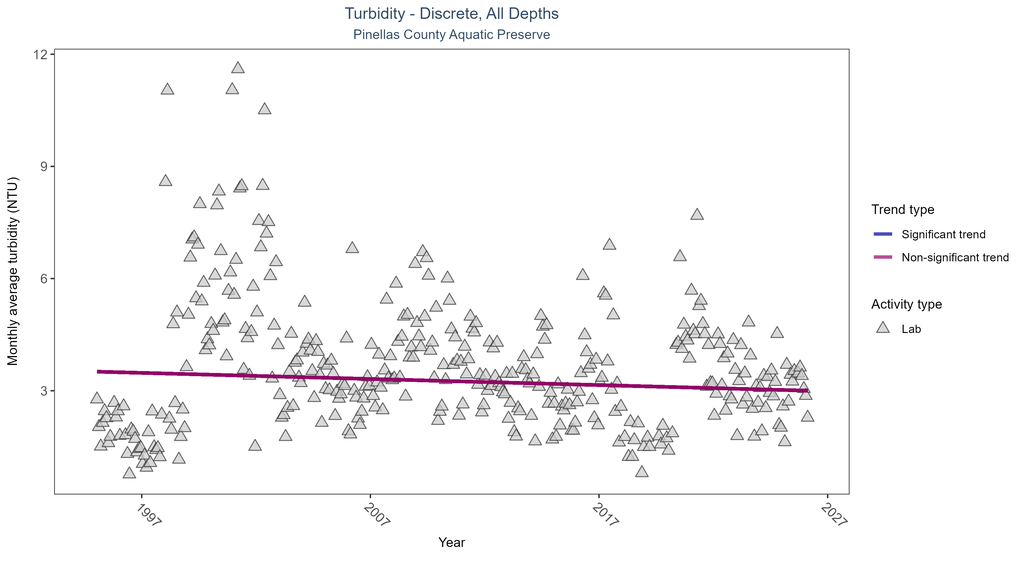

Scatter plot of monthly average turbidity over time. If the time series included ten or more years of discrete observations, a significant (blue) or non-significant (magenta) trend line is also shown. Only turbidity values measured in the laboratory (triangles) are included in the plot.

Table:

Turbidity showed no detectable trend between 1995 and 2026.

| Activity Type | Statistical Trend | Sample Count | Years with Data | Period of Record | Median Result Value | Tau | Sen Intercept | Sen Slope | P |
| --- | --- | --- | --- | --- | --- | --- | --- | --- | --- |
| Lab | No detectable trend | 21901 | 32 | 1995 - 2026 | 2.5 | -0.05944 | 3.50994 | -0.01632 | 0.1087 |

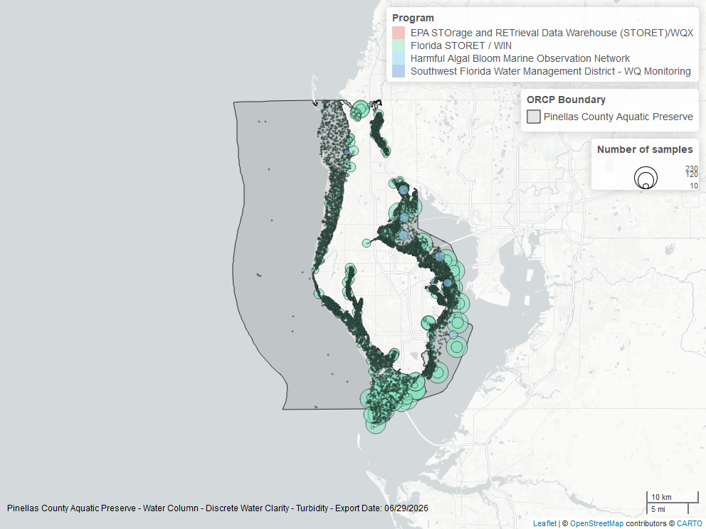

Map showing location of discrete water quality sampling locations within the boundaries of *Pinellas County Aquatic Preserve*. The bubble size on the maps above reflect the amount of data available at each sampling site.

### Total Suspended Solids - Discrete

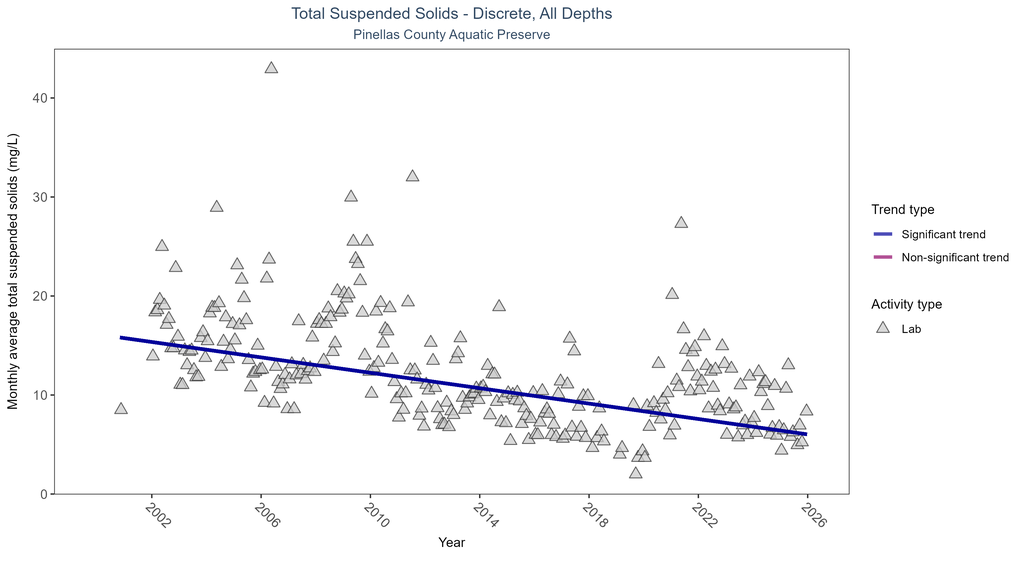

Scatter plot of monthly average total suspended solids (TSS) over time. If the time series included ten or more years of discrete observations, a significant (blue) or non-significant (magenta) trend line is also shown. Only TSS values obtained from laboratory analyses (triangles) are included in the plot.

Table:

Monthly average total suspended solids decreased by 0.39 mg/L per year, indicating an increase in water clarity.

| Activity Type | Statistical Trend | Sample Count | Years with Data | Period of Record | Median Result Value | Tau | Sen Intercept | Sen Slope | P |
| --- | --- | --- | --- | --- | --- | --- | --- | --- | --- |
| Lab | Decreasing trend | 12811 | 25 | 2000 - 2025 | 10 | -0.43007 | 16.13379 | -0.38889 | 0 |

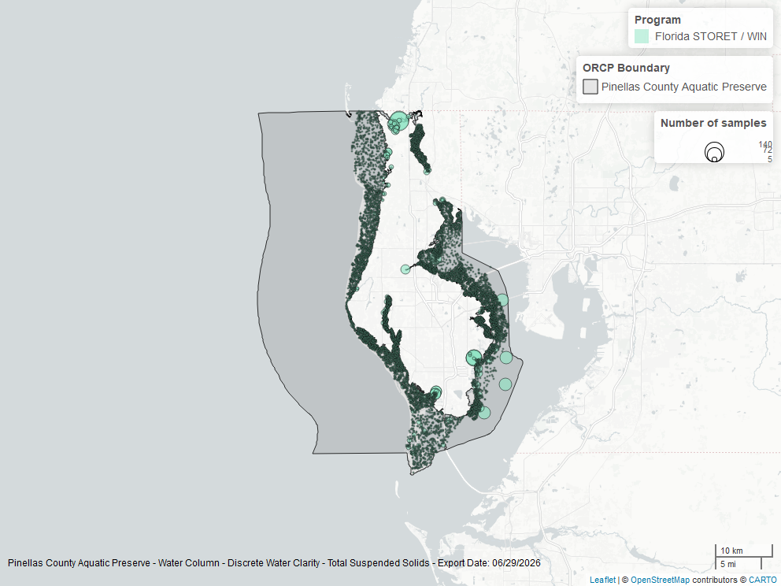

Map showing location of discrete water quality sampling locations within the boundaries of *Pinellas County Aquatic Preserve*. The bubble size on the maps above reflect the amount of data available at each sampling site.

### Chlorophyll a, Uncorrected for Pheophytin - Discrete

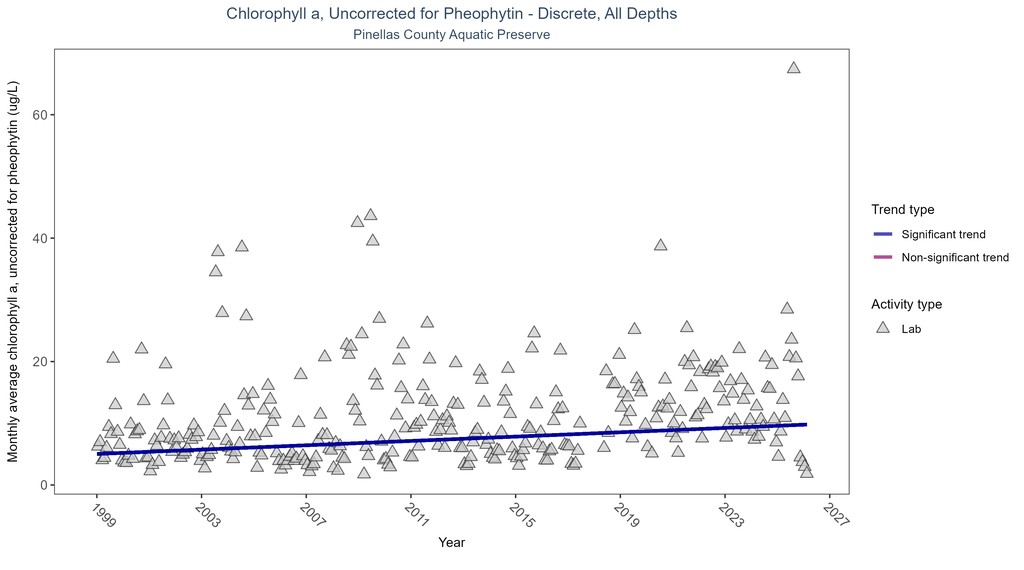

Scatter plot of monthly average levels of chlorophyll a, uncorrected for pheophytin, over time. If the time series included ten or more years of discrete observations, a significant (blue) or non-significant (magenta) trend line is also shown. Only laboratory-analyzed chlorophyll a (triangles) is included in the plot.

Table:

Monthly average chlorophyll a, uncorrected for pheophytin, increased by 0.18 µg/L per year, indicating a decrease in water clarity.

| Activity Type | Statistical Trend | Sample Count | Years with Data | Period of Record | Median Result Value | Tau | Sen Intercept | Sen Slope | P |
| --- | --- | --- | --- | --- | --- | --- | --- | --- | --- |
| Lab | Increasing trend | 7261 | 28 | 1999 - 2026 | 6.3 | 0.25468 | 5.03124 | 0.1756 | 0 |

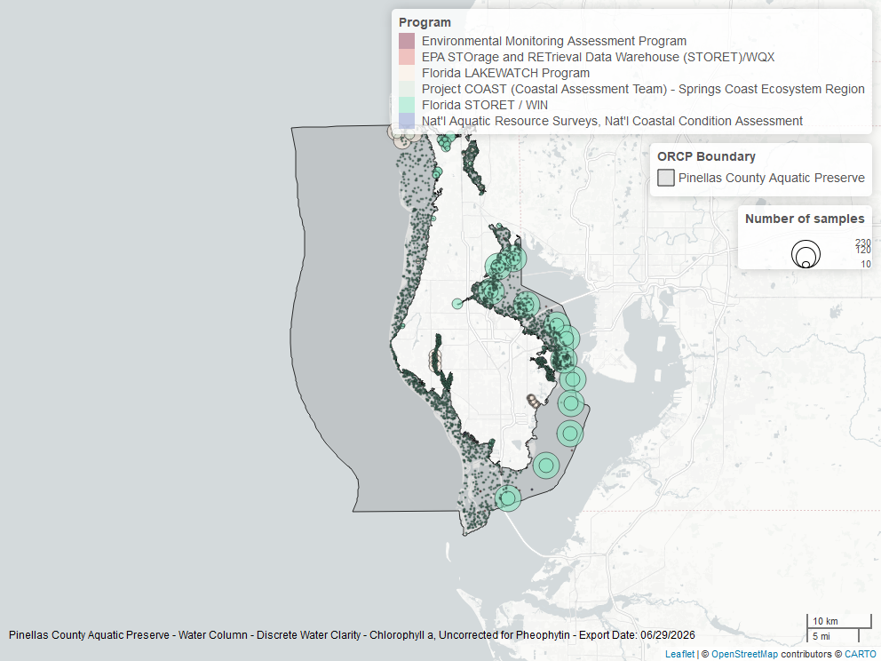

Map showing location of discrete water quality sampling locations within the boundaries of *Pinellas County Aquatic Preserve*. The bubble size on the maps above reflect the amount of data available at each sampling site.

### Chlorophyll a, Corrected for Pheophytin - Discrete

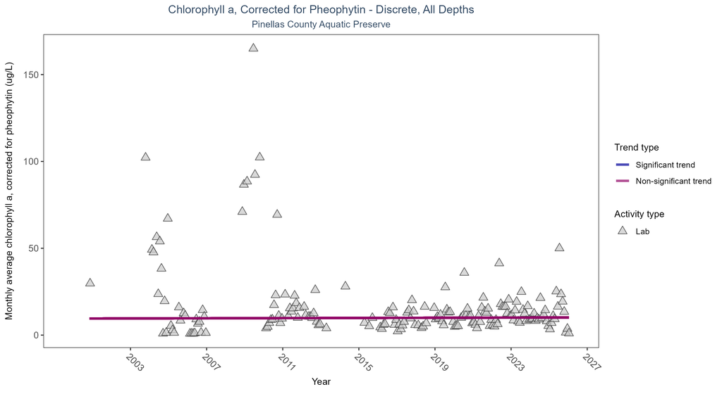

Scatter plot of monthly average levels of chlorophyll a, corrected for pheophytin, over time. If the time series included ten or more years of discrete observations, a significant (blue) or non-significant (magenta) trend line is also shown. Only laboratory-analyzed chlorophyll a (triangles) is included in the plot.

Table:

Chlorophyll a, corrected for pheophytin, showed no detectable trend between 2000 and 2026.

| Activity Type | Statistical Trend | Sample Count | Years with Data | Period of Record | Median Result Value | Tau | Sen Intercept | Sen Slope | P |
| --- | --- | --- | --- | --- | --- | --- | --- | --- | --- |
| Lab | No detectable trend | 3842 | 24 | 2000 - 2026 | 5.7 | 0.01891 | 9.52955 | 0.02308 | 0.7388 |

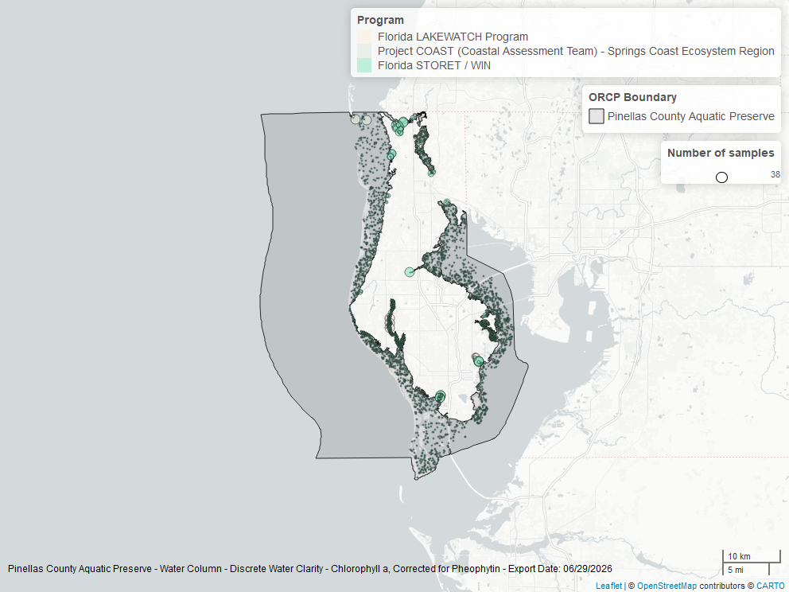

Map showing location of discrete water quality sampling locations within the boundaries of *Pinellas County Aquatic Preserve*. The bubble size on the maps above reflect the amount of data available at each sampling site.

### Secchi Depth - Discrete

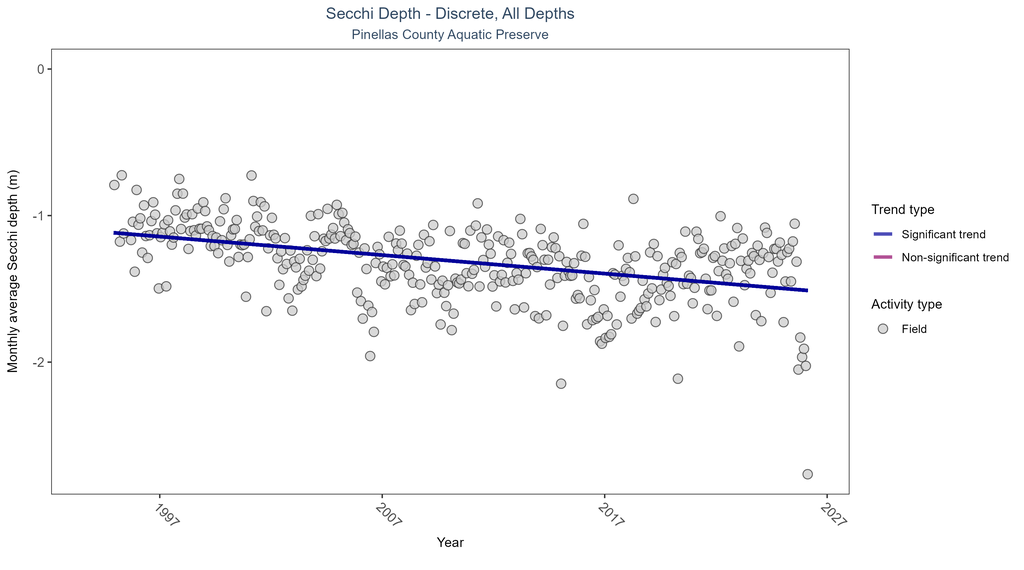

Scatter plot of monthly average Secchi depth over time. If the time series included ten or more years of discrete observations, a significant (blue) or non-significant (magenta) trend line is also shown. Secchi depth is only measured in the field (circles).

Table:

Monthly average Secchi depth became deeper by 0.01 m per year, indicating an increase in water clarity.

| Activity Type | Statistical Trend | Sample Count | Years with Data | Period of Record | Median Result Value | Tau | Sen Intercept | Sen Slope | P |
| --- | --- | --- | --- | --- | --- | --- | --- | --- | --- |
| Field | Decreasing trend | 32881 | 33 | 1994 - 2026 | -1.2 | -0.33576 | -1.1054 | -0.01263 | 0 |

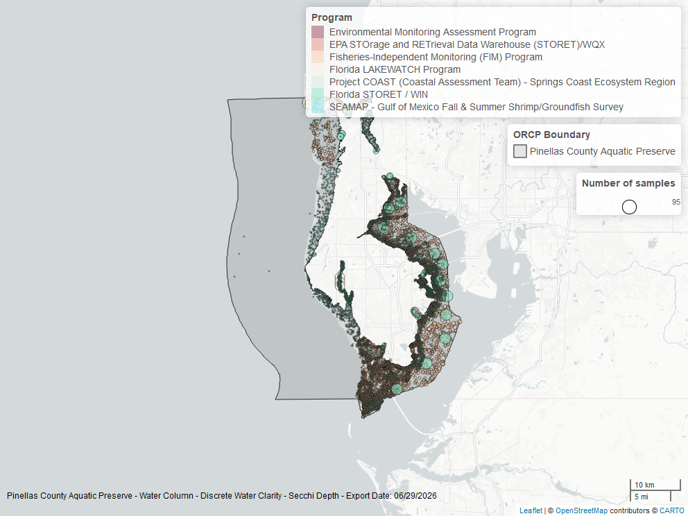

Map showing location of discrete water quality sampling locations within the boundaries of *Pinellas County Aquatic Preserve*. The bubble size on the maps above reflect the amount of data available at each sampling site.

### Colored Dissolved Organic Matter - Discrete

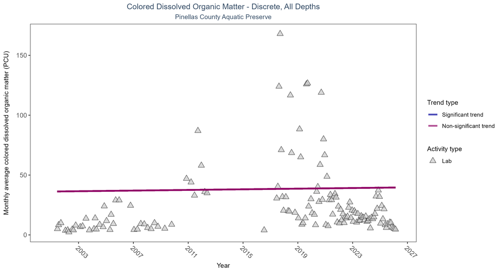

Scatter plot of monthly average colored dissolved organic matter (CDOM) over time. If the time series included ten or more years of discrete observations, a significant (blue) or non-significant (magenta) trend line is also shown. Only laboratory-analyzed CDOM (triangles) is included in the plot.

Table:

Colored dissolved organic matter showed no detectable trend between 2001 and 2026.

| Activity Type | Statistical Trend | Sample Count | Years with Data | Period of Record | Median Result Value | Tau | Sen Intercept | Sen Slope | P |
| --- | --- | --- | --- | --- | --- | --- | --- | --- | --- |
| Lab | No detectable trend | 1435 | 23 | 2001 - 2026 | 10 | 0.00053 | 36.23007 | 0.13333 | 0.2634 |

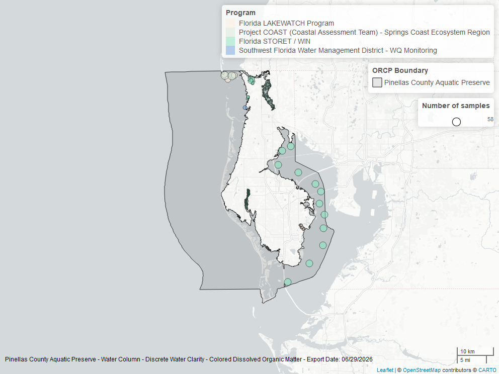

Map showing location of discrete water quality sampling locations within the boundaries of *Pinellas County Aquatic Preserve*. The bubble size on the maps above reflect the amount of data available at each sampling site.